# Introduction to programming in R

Julia Ruhle & Leone Albinati

26th and 27th of May 2025

# 1 Course organization

> **Day 1 (26th of May):**
> - Refreshing data manipulation with R
> - The amazing world of tidyverse

> **Day 2 (27th of May):**
> - The basics of plotting - ggplot2
> - Final exercise

## 1.1 Set up things

- The path of your computer should be “/home/training/”. Check if it is with getwd()
- In “/home/training/” create a new folder called “tidyverse_course_2025”: this folder will be used to store all the outputs/inputs/scripts of this course
- Use the same computer for both sessions - at the end of the course mail yourself everything you want to keep.
- Check if everything is installed - load the libraries we are going to use

```r
# install the libraries - DO NOT RUN
install.packages("tidyverse")
install.packages("ggpubr")
install.packages("patchwork")

# check libraries are installed
library(tidyverse)
library(ggpubr)
library(patchwork)
```

## 1.2 Before we start

> **Important note**

> Now we are going to refresh data frames and how to manipulate them in **base R**. Data frames - and tibbles - are the main data structure that we use when working with **tidyverse**. Most of the things that we do in tidyverse can be done with basic R, but tidyverse makes coding much more understandable. Many codes are written using tidyverse and often ChatGPT and other language models suggest codes using tidyverse. Moreover, the well known package **ggplot** (the reason many of you are here?) is developed inside tidyverse. The way tidyverse handles data structures is different from how we do it with basic R. Still, refreshing how basic R works will make us understand better the power of tidyverse.

## 1.3 Data frames

- A data frame is a **two-dimensional** element.
- Differently from the matrix, can contain **different data types**.
- Still, each column should be of a specific data type.
- It is generally organized by columns (that are the **variables**) and each row is an **observation** for that variable.

### 1.3.1 Create a data frame

- Generally we can create a data frame from the scratch or converting other structures (like matrices)

```r
# How to create a dataframe
people <- data.frame(name=c("Leone","Julia","Luisa"),
                     age=c(31,30,28),
                     italian=c(T,F,T))

# main check for data frames
dim(people)
head(people)
colnames(people)
```

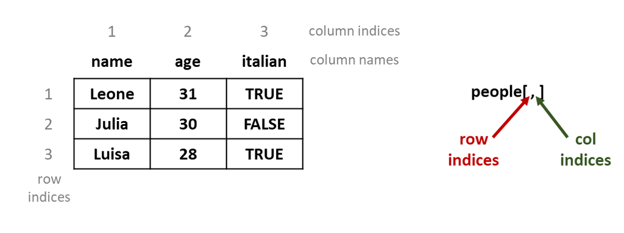

- We can access the elements in the dataframe with their **indices** or with their **colnames**

```r
# these two are the same
people[,1]
people[,"name"]
```

- **Important**: for data frames, we can retrieve columns using the **dollar symbol**

```r
# these two are the same
people[,"name"]
people$name

# we can even create a new column using the dollar symbol
people$beach_volley <- c(F,T,T)
people
```

### 1.3.2 Data frame manipulation

- We manipulate data frame as if they were **vectors but in two dimensions**!

```r
# these command all output the same
people[people[,2]>=30,]
people[people[,"age"]>=30,]
people[people$age>=30,] # BEST OPTION! We prefer to use the dollar with data frames

# let's see it line by line to understand what we are doing
# 1. Extract the column with the $ sign
people$age

# 2. check for your condition of interest (i.e. age >= 30)
people$age >= 30

# subset the data frame to select only the rows that fulfill the condition
people[people$age >= 30,]
```

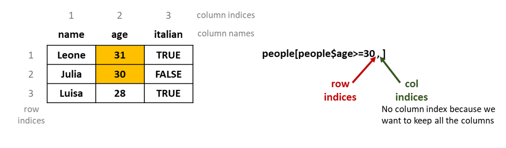

- Of course, we can select for multiple criterias

```r
# select the people that have more or equal than 30 yo and that are not from Italy
people[people$age >= 30 & people$italian==FALSE,]
# select the people that are less than 30 yo or that play beachvolley
people[people$age < 30 | people$beach_volley==TRUE,]
```

#### 1.3.2.1 Ultra-quick HANDS-ON

- What is the age of the italian beach-volleyball player? No manual counting, let’s store the output in an object called **italian_bv_age**

**Answer**

```r
# select the people that play bv and that are from Italy
italian_bv <- people[people$beach_volley == TRUE & people$italian==TRUE,]
# extract the column with the age and assign
italian_bv_age <- italian_bv$age
```

### 1.3.3 Selection based on patterns

- We can also subset dataframes based on patterns

```r
# We can add a new column based on where these people are located
people$location <- c("sixth_office6","fourth_office3","fourth_office6")

# How can we select the people that work at the 4th floor
# we can select base on pattern using the grep function
# Let's see it line by line
people$location
grep(pattern = "fourth",x = people$location)
people[grep(pattern = "fourth",x = people$location),]
fourth_floor_people <- people[grep(pattern = "fourth",x = people$location),]
# grep has other interesting arguments, check n the help manual
```

# 2 Summary exercise

```r
# load the iris dataset - to load it we use the function data()
data(iris)

# let's check the first columns to understand this dataset
head(iris)
```

|  | Sepal.Length | Sepal.Width | Petal.Length | Petal.Width | Species |
| --- | --- | --- | --- | --- | --- |
| 1 | 5.1 | 3.5 | 1.4 | 0.2 | setosa |
| 2 | 4.9 | 3.0 | 1.4 | 0.2 | setosa |
| 3 | 4.7 | 3.2 | 1.3 | 0.2 | setosa |
| 4 | 4.6 | 3.1 | 1.5 | 0.2 | setosa |
| 5 | 5.0 | 3.6 | 1.4 | 0.2 | setosa |
| 6 | 5.4 | 3.9 | 1.7 | 0.4 | setosa |

**Answer**

```r
# 2. Check and change working directory
getwd()
setwd("home/training/Rcourse_2025")

# 4. Calculate mean of petal length
mean(iris$Petal.Length)

# 5. Data frame without setosa
no_setosa <- iris[iris$Species!="setosa",]
nrow(no_setosa) # to know the n of observations

# 6. Select for multiple conditions
selection <- no_setosa[no_setosa$Petal.Length>4&no_setosa$Sepal.Width<3,]

# 7. Counting observation in one column
table(selection$Species)
# other solution might be to subset the dataframe for our condition and count
nrow(selection[selection$Species=="virginica",])
nrow(selection[selection$Species=="versicolor",])

# 8. Create a new vector
interesting <- c("setosa","virginica")

# 9. Subset iris for common elements with the interesting vectors
subset <- iris[iris$Species%in%interesting,]
```